# **Non-Linear Dimensionality Reduction Techniques for Single-Cell Transcriptomics**

**Emily Liau from [BIOINFORMATICS++](https://learningbioinformatics.substack.com/)**

## **Overview**

In this tutorial, we will apply two non-linear dimensionality reduction techniques (t-SNE, UMAP) to visualize and annotate major cell types within a single-cell RNA-seq dataset of the small intestinal epithelium from Mus musculus, curated by [Haber et al. (2017)](https://doi.org/10.1038/nature24489).

## **Mount Google Drive**

To access files within your Google Drive, mount your Google Drive to Google Colaboratory and establish your working directory by executing the following blocks of code.

```python
from google.colab import drive
import os
```

```python
def mount_google_drive(my_folder):
  root = '/content/drive'
  drive.mount(root, force_remount = True)
  dest_folder = root + '/My Drive' + my_folder
  os.chdir(dest_folder)

  curr_path = os.getcwd()
  if (len(curr_path) > 0):
    print('Current Path: ', os.getcwd())
    return curr_path
  else:
    raise Exception('\n Failed to Mount Google Drive\n')
```

```python
my_folder = '/Colab Notebooks/BIOINFORMATICS++/NLDR/'
curr_path = mount_google_drive(my_folder)
```

```
Current Path:  /content/drive/My Drive/Colab Notebooks/BIOINFORMATICS++/NLDR
```

The scRNA-seq analysis workflow encompasses quality control (QC), normalization, feature selection, dimensionality reduction, and clustering ([Slovin et al., 2021](https://doi.org/10.1007/978-1-0716-1307-8_19)). Overall, the established thresholds and parameters may have a substantial impact on the results obtained from downstream analyses. The subsequent components of this tutorial provide an overview of various stages of the scRNA-seq workflow, from data pre-processing through dimensionality reduction.

## **Single-Sample (GSM2836573)**

First, we will perform data pre-processing and dimensionality reduction on GSM2836573, which requires the following files:

- GSM2836573_Regional_Duo_M1_barcodes.tsv.gz
- GSM2836573_Regional_Duo_M1_genes.tsv.gz
- GSM2836573_Regional_Duo_M1_matrix.mtx.gz

### **Data Description & Pre-Processing**

To facilitate data pre-processing for all samples, we will utilize the following packages:

- scanpy: A module for analyzing scRNA-seq data, including functionality for data pre-processing, visualization, clustering, etc.
- tarfile: A module that provides read/write functionality for compressed archives

```python
# scanpy installation
!pip install scanpy
```

```python
# import requisite packages for data pre-processing
import numpy as np
import pandas as pd
import scanpy as sc
import tarfile
```

The data for this tutorial are publicly-available, and can be obtained from [GSE92332](https://www.ncbi.nlm.nih.gov/geo/download/?acc=GSE92332&format=file) on NCBI GEO. Within this scRNA-seq experiment, [Haber et al. (2017)](https://doi.org/10.1038/nature24489) sought to leverage high-throughput sequencing to extract and process individual cells, in order to establish cell state diversity within the small intestinal epithelium of Mus musculus.

Upload the GSE92332_RAW.tar file to Google Drive, and execute the following code block to extract its contents.

```python
# extract contents of .tar file
with tarfile.open("GSE92332_RAW.tar") as tar:
  tar.extractall("data/GSE92332/")
```

```python
# print current working directory
file_dir = '/content/drive/My Drive/Colab Notebooks/BIOINFORMATICS++/NLDR/data/GSE92332/'
print(file_dir)
```

```
/content/drive/My Drive/Colab Notebooks/BIOINFORMATICS++/NLDR/data/GSE92332/
```

The data for this tutorial are structured as filtered feature-barcode matrices from [Cell Ranger by 10x Genomics](https://support.10xgenomics.com/single-cell-gene-expression/software/pipelines/latest/algorithms/overview), with features as rows and barcodes as columns. In a filtered feature-barcode matrix, only cell-associated barcodes are included, and all non-targeted genes are removed during the processing stage.

- barcodes.tsv.gz: cellular barcodes
- genes.tsv.gz: ID values of quantified genes
- matrix.tsv.gz: a matrix of count values, with rows as gene IDs and columns as cellular barcodes

After isolating the required files within your working directory, execute the following code block to output a list of all file names in the folder.

```python
# list all file names in folder
file_list = sorted(os.listdir(file_dir))

for file_name in file_list:
  if os.path.isfile(os.path.join(file_dir, file_name)):
    print(file_name)
```

```
GSM2836573_Regional_Duo_M1_barcodes.tsv.gz
GSM2836573_Regional_Duo_M1_genes.tsv.gz
GSM2836573_Regional_Duo_M1_matrix.mtx.gz
GSM2836574_Regional_Duo_M2_barcodes.tsv.gz
GSM2836574_Regional_Duo_M2_genes.tsv.gz
GSM2836574_Regional_Duo_M2_matrix.mtx.gz
GSM2836575_Regional_Jej_M1_barcodes.tsv.gz
GSM2836575_Regional_Jej_M1_genes.tsv.gz
GSM2836575_Regional_Jej_M1_matrix.mtx.gz
GSM2836576_Regional_Jej_M2_barcodes.tsv.gz
GSM2836576_Regional_Jej_M2_genes.tsv.gz
GSM2836576_Regional_Jej_M2_matrix.mtx.gz
GSM2836577_Regional_Il_M1_barcodes.tsv.gz
GSM2836577_Regional_Il_M1_genes.tsv.gz
GSM2836577_Regional_Il_M1_matrix.mtx.gz
GSM2836578_Regional_Il_M2_barcodes.tsv.gz
GSM2836578_Regional_Il_M2_genes.tsv.gz
GSM2836578_Regional_Il_M2_matrix.mtx.gz
GSM2836579_LargeCell_M1_B1_barcodes.tsv.gz
GSM2836579_LargeCell_M1_B1_genes.tsv.gz
GSM2836579_LargeCell_M1_B1_matrix.mtx.gz
GSM2836580_LargeCell_M1_B2_barcodes.tsv.gz
GSM2836580_LargeCell_M1_B2_genes.tsv.gz
GSM2836580_LargeCell_M1_B2_matrix.mtx.gz
GSM2836581_LargeCell_M1_B3_barcodes.tsv.gz
GSM2836581_LargeCell_M1_B3_genes.tsv.gz
GSM2836581_LargeCell_M1_B3_matrix.mtx.gz
GSM2836582_LargeCell_M1_B4_barcodes.tsv.gz
GSM2836582_LargeCell_M1_B4_genes.tsv.gz
GSM2836582_LargeCell_M1_B4_matrix.mtx.gz
GSM2836583_LargeCell_M1_B5_barcodes.tsv.gz
GSM2836583_LargeCell_M1_B5_genes.tsv.gz
GSM2836583_LargeCell_M1_B5_matrix.mtx.gz
GSM2836584_LargeCell_M2_B6_barcodes.tsv.gz
GSM2836584_LargeCell_M2_B6_genes.tsv.gz
GSM2836584_LargeCell_M2_B6_matrix.mtx.gz
GSM2836585_LargeCell_M2_B7_barcodes.tsv.gz
GSM2836585_LargeCell_M2_B7_genes.tsv.gz
GSM2836585_LargeCell_M2_B7_matrix.mtx.gz
GSM2836586_Salmonella_M1_barcodes.tsv.gz
```

[output cut: 83 more lines]

```
GSM2839469_FAE.epi1.GFI1B-_barcodes.tsv.gz
GSM2839469_FAE.epi1.GFI1B-_genes.tsv.gz
GSM2839469_FAE.epi1.GFI1B-_matrix.mtx.gz
GSM2839470_FAE.epi2.GFI1B-_barcodes.tsv.gz
GSM2839470_FAE.epi2.GFI1B-_genes.tsv.gz
GSM2839470_FAE.epi2.GFI1B-_matrix.mtx.gz
GSM2839471_FAE.Mcell.GFI1B+_barcodes.tsv.gz
GSM2839471_FAE.Mcell.GFI1B+_genes.tsv.gz
GSM2839471_FAE.Mcell.GFI1B+_matrix.mtx.gz
GSM4521364_FAE.epi3.WT_barcodes.tsv.gz
GSM4521364_FAE.epi3.WT_genes.tsv.gz
GSM4521364_FAE.epi3.WT_matrix.mtx.gz
GSM4521365_FAE.epi4.WT_barcodes.tsv.gz
GSM4521365_FAE.epi4.WT_genes.tsv.gz
GSM4521365_FAE.epi4.WT_matrix.mtx.gz
```

Parse the components of each file name prior to reading the data files into your local environment.

```python
# extract identifiers from file names
file_list_base = []

for file in file_list:
  parts = file.split("_")
  if parts[0] not in file_list_base:
    file_list_base.append(parts[0])
print(file_list_base)
```

```
['GSM2836573', 'GSM2836574', 'GSM2836575', 'GSM2836576', 'GSM2836577', 'GSM2836578', 'GSM2836579', 'GSM2836580', 'GSM2836581', 'GSM2836582', 'GSM2836583', 'GSM2836584', 'GSM2836585', 'GSM2836586', 'GSM2836587', 'GSM2836588', 'GSM2836589', 'GSM2839445', 'GSM2839446', 'GSM2839447', 'GSM2839448', 'GSM2…
```

```python
# parse components of file names
string_headers = ['Duo_M1', 'Duo_M2', 'Jej_M1', 'Jej_M2', 'Il_M1', 'Il_M2']
id_values = ['3', '4', '5', '6', '7', '8']
file_base = 'GSM283657'
middle_string = '_Regional_'
mtx_suffix = '_matrix.mtx.gz'
barcode_suffix = '_barcodes.tsv.gz'
gene_suffix = '_genes.tsv.gz'
```

.matrix.mtx.gz files are read as annotated data matrices, where each data matrix is associated with annotations of observations. Prior to appending samples to the data object, we must initialize the annotated data matrix using the first sample in the directory, Duo_M1.

Each data matrix contains the following features:

- sample: sample id (Duo_M1, Duo_M2, Jej_M1, Jej_M2, Il_M1, Il_M2)
- region: region of the small intestine (duodenum, jejunum, ileum)
- donor: sample donor (M1, M2)
- n_counts: number of counts
- log_counts: number of log-transformed counts
- n_genes: number of genes

```python
# structure file names
header = string_headers.pop(0)
id = id_values.pop(0)
mtx_file = file_dir + file_base + id + middle_string + header + mtx_suffix
barcode_file = file_dir + file_base + id + middle_string + header + barcode_suffix
gene_file = file_dir + file_base + id + middle_string + header + gene_suffix

# load and format matrix data with scanpy
data = sc.read(mtx_file, cache = True)
data = data.transpose()
data.X = data.X.toarray()

# read barcodes and genes from .csv files
barcodes = pd.read_csv(barcode_file, header = None, sep = '\t')
genes = pd.read_csv(gene_file, header = None, sep = '\t')

# annotate data
barcodes.rename(columns = {0:'barcode'}, inplace = True)
barcodes.set_index('barcode', inplace = True)
data.obs = barcodes
data.obs['sample'] = [header] * data.n_obs
data.obs['region'] = [header.split("_")[0]] * data.n_obs
data.obs['donor'] = [header.split("_")[1]] * data.n_obs
genes.rename(columns = {0:'gene_id', 1:'gene_symbol'}, inplace = True)
genes.set_index('gene_symbol', inplace = True)

# filter out low-quality reads via thresholding
data.obs['n_counts'] = data.X.sum(1)
data.obs['log_counts'] = np.log(data.obs['n_counts'])
data.obs['n_genes'] = (data.X > 0).sum(1)
```

```python
# view data
data.obs.reset_index()
```

|  | barcode | sample | region | donor | n_counts | log_counts | n_genes |
| --- | --- | --- | --- | --- | --- | --- | --- |
| 0 | AAACATACAGCGGA-1 | Duo_M1 | Duo | M1 | 12770.0 | 9.454854 | 1227 |
| 1 | AAACATACCTTACT-1 | Duo_M1 | Duo | M1 | 6587.0 | 8.792853 | 2156 |
| 2 | AAACATACTTTGCT-1 | Duo_M1 | Duo | M1 | 2844.0 | 7.952967 | 1424 |
| 3 | AAACCGTGCAGTCA-1 | Duo_M1 | Duo | M1 | 2799.0 | 7.937017 | 1362 |
| 4 | AAACGCTGCAGTCA-1 | Duo_M1 | Duo | M1 | 6050.0 | 8.707813 | 2287 |
| ... | ... | ... | ... | ... | ... | ... | ... |
| 2343 | TTTATCCTATGACC-1 | Duo_M1 | Duo | M1 | 4775.0 | 8.471149 | 1924 |
| 2344 | TTTATCCTTCTCGC-1 | Duo_M1 | Duo | M1 | 3401.0 | 8.131824 | 1436 |
| 2345 | TTTCACGAAACGTC-1 | Duo_M1 | Duo | M1 | 4218.0 | 8.347116 | 1784 |
| 2346 | TTTCTACTACTGGT-1 | Duo_M1 | Duo | M1 | 3352.0 | 8.117312 | 1491 |
| 2347 | TTTGACTGCGGAGA-1 | Duo_M1 | Duo | M1 | 4953.0 | 8.507749 | 1822 |

2348 rows × 7 columns

### **t-SNE**

The following sections outline examples of applying t-SNE on the Duo_M1 samples with the Louvain and Leiden algorithms.

#### **Louvain (resolution = 1)**

```python
# louvain algorithm installation
!pip install louvain
```

```
     ━━━━━━━━━━━━━━━━━━━━━━━━━━━━━━━━━━━━━━━━ 1.1/1.1 MB 23.5 MB/s eta 0:00:00
     ━━━━━━━━━━━━━━━━━━━━━━━━━━━━━━━━━━━━━━━━ 3.3/3.3 MB 83.3 MB/s eta 0:00:00
```

```python
import louvain
```

The igraph package supports the manipulation, visualization, and analysis of graphs and networks.

```python
# igraph installation
!pip install igraph
```

```python
import igraph
```

Prior to performing dimensionality reduction with t-SNE, construct the neighborhood graph of the observations within the Duo_M1 data.

```python
# construct the neighborhood graph
sc.pp.neighbors(data)
```

```
WARNING: You’re trying to run this on 27998 dimensions of `.X`, if you really want this, set `use_rep='X'`.
         Falling back to preprocessing with `sc.pp.pca` and default params.
```

Apply t-SNE on the Duo_M1 data with 3 threads, the number of parallel jobs to execute during the neighbors search.

```python
# construct t-sne
sc.tl.tsne(data, n_jobs = 3)
```

Plot t-SNE with the Louvain clustering algorithm using the default resolution parameter of 1.

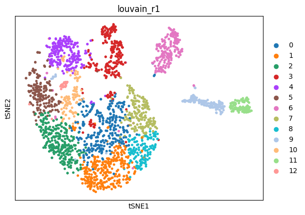

```python
# construct and plot t-sne with louvain algorithm (resolution = 1)
sc.tl.louvain(data, key_added = 'louvain_r1')
sc.pl.tsne(data, color = ['louvain_r1'])
```

#### **Louvain (resolution = 0.5)**

```python
# construct t-sne with louvain algorithm (resolution = 0.5)
sc.tl.louvain(data, resolution = 0.5, key_added = 'louvain_r0.5')
```

```python
# rename categories based on small intestinal cell type
data.obs['louvain_r0.5'].cat.categories
data.rename_categories('louvain_r0.5', ['TA', 'EP (early)', 'Stem', 'Goblet', 'EP (stress)', 'Enterocyte', 'Paneth', 'Tuft'])
```

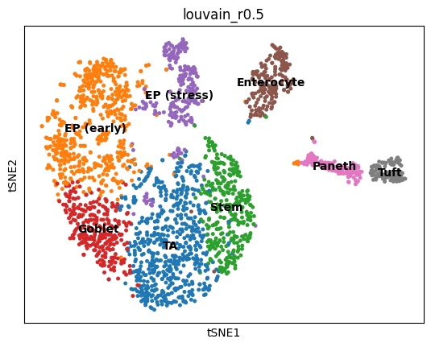

```python
# plot t-sne with louvain algorithm (resolution = 0.5)
sc.pl.tsne(data, color = ['louvain_r0.5'], legend_loc = 'on data')
```

#### **PAGA (Louvain, resolution = 0.5)**

According to [Wolf et al. (2019)](https://doi.org/10.1186/s13059-019-1663-x), partition-based graph abstraction (PAGA) generates a topological representation of samples in a dataset, and is commonly applied towards scRNA-seq data to preserve the underlying structure of the samples at various resolutions. PAGA graphs are constructed by associating nodes with partitions, and linking nodes based on the degree of connectivity between partitions. A path in a PAGA graph is the average of all single-cell paths that traverse through a group of cells, allowing individuals to assess the trajectory of the variation in gene expression at the cellular level. The size of the nodes are proportional to the number of cells in the cluster, and the thickness of the edges represent the degree of connectivity.

Construct the PAGA for the t-SNE embedding with the Louvain algorithm at resolution = 0.5.

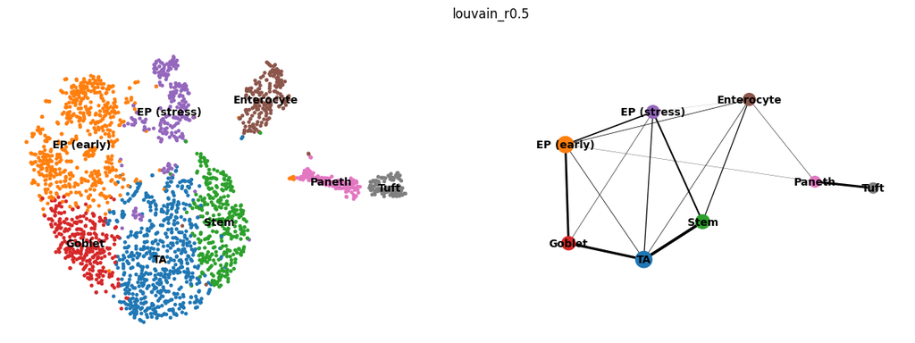

```python
# construct and plot paga with louvain algorithm (resolution = 0.5)
sc.tl.paga(data, groups = 'louvain_r0.5')
sc.pl.paga_compare(data, basis = 'tsne')
```

#### **Leiden (resolution = 1)**

According to [Traag et al. (2019)](https://doi.org/10.1038/s41598-019-41695-z), the Leiden algorithm serves to create an aggregate network based on partitions from local node movement. Compared to the Louvain algorithm, the Leiden algorithm is more complex, as it includes a refinement stage when establishing partitions.  
Prior to applying t-SNE on the Duo_M1 samples, apply the Leiden clustering algorithm with various resolutions on the Duo_M1 samples.

```python
# leiden algorithm installation
!pip install leidenalg
```

```
     ━━━━━━━━━━━━━━━━━━━━━━━━━━━━━━━━━━━━━━━━ 1.3/1.3 MB 23.9 MB/s eta 0:00:00
```

```python
import leidenalg
```

Construct and plot t-SNE with the Leiden clustering algorithm using the default resolution parameter of 1.

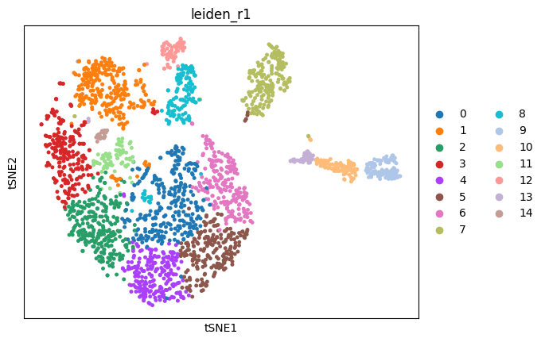

```python
# construct and plot t-sne with leiden algorithm (resolution = 1)
sc.tl.leiden(data, key_added = 'leiden_r1')
sc.pl.tsne(data, color = ['leiden_r1'])
```

#### **Leiden (resolution = 0.5)**

```python
# construct t-sne with leiden algorithm (resolution = 0.5)
sc.tl.leiden(data, resolution = 0.5, key_added = 'leiden_r0.5')
```

```python
# rename categories based on small intestinal cell type
data.obs['leiden_r0.5'].cat.categories
data.rename_categories('leiden_r0.5', ['Enteroendocrine', 'TA', 'EP (early)', 'Stem', 'Goblet', 'EP (stress)', 'Enterocyte', 'Paneth', 'Neuroendocrine', 'Tuft'])
```

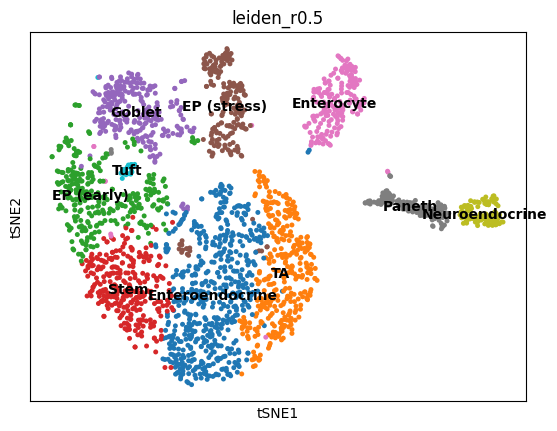

```python
# plot t-sne with leiden algorithm (resolution = 0.5)
sc.pl.tsne(data, color = ['leiden_r0.5'], legend_loc = 'on data')
```

#### **PAGA (Leiden, resolution = 0.5)**

Construct the PAGA for the t-SNE embedding with the Leiden clustering algorithm at resolution = 0.5.

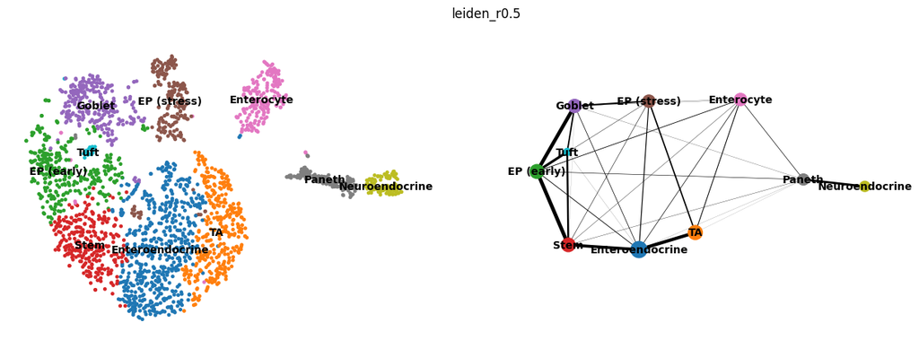

```python
# construct and plot paga with leiden algorithm (resolution = 0.5)
sc.tl.paga(data, groups = 'leiden_r0.5')
sc.pl.paga_compare(data, basis = 'tsne')
```

### **UMAP**

The following sections outline examples of applying UMAP on the Duo_M1 samples with the Louvain and Leiden algorithms.

```python
# construct umap
sc.tl.umap(data)
```

Prior to applying UMAP on the Duo_M1 samples, apply the Louvain clustering algorithm ([Blondel et al., 2008](https://arxiv.org/pdf/0803.0476.pdf)) with various resolutions on the Duo_M1 samples.

#### **Louvain Algorithm (resolution = 1)**

Plot UMAP with the Louvain clustering algorithm using the default resolution parameter of 1.

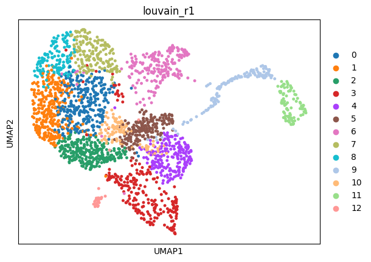

```python
# construct umap with louvain algorithm (resolution = 1)
sc.tl.louvain(data, key_added = 'louvain_r1')
sc.pl.umap(data, color = ['louvain_r1'])
```

#### **Louvain Algorithm (resolution = 0.5)**

```python
# construct umap with louvain algorithm (resolution = 0.5)
sc.tl.louvain(data, resolution = 0.5, key_added = 'louvain_r0.5')
```

```python
# rename categories based on small intestinal cell type
data.obs['louvain_r0.5'].cat.categories
data.rename_categories('louvain_r0.5', ['TA', 'EP (early)', 'Stem', 'Goblet', 'EP (stress)', 'Enterocyte', 'Paneth', 'Enteroendocrine'])
```

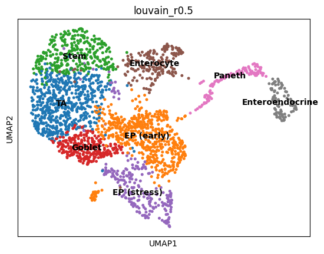

```python
# plot umap with louvain algorithm (resolution = 0.5)
sc.pl.umap(data, color = ['louvain_r0.5'], legend_loc = 'on data')
```

#### **PAGA (Louvain Algorithm, resolution = 0.5)**

Construct the PAGA for the UMAP embedding with the Louvain clustering algorithm at resolution = 0.5.

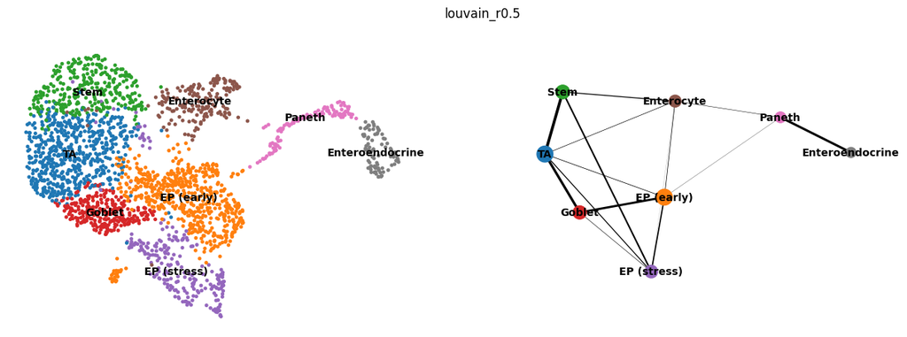

```python
# construct and plot paga with louvain algorithm (resolution = 0.5)
sc.tl.paga(data, groups = 'louvain_r0.5')
sc.pl.paga_compare(data, basis = 'umap')
```

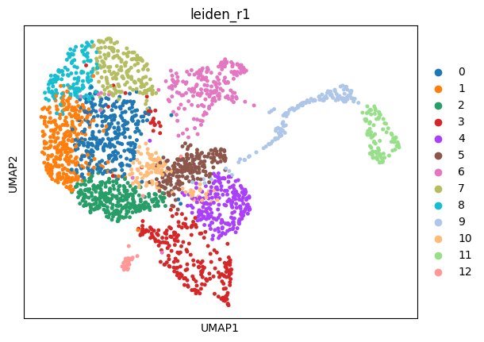

```python
# construct umap with leiden algorithm (resolution = 1)
sc.tl.louvain(data, key_added = 'leiden_r1')
sc.pl.umap(data, color = ['leiden_r1'])
```

#### **Leiden Algorithm (resolution = 0.5)**

```python
# construct umap with leiden algorithm (resolution = 0.5)
sc.tl.leiden(data, resolution = 0.5, key_added = 'leiden_r0.5')
```

```python
# rename categories based on small intestinal cell type
data.obs['leiden_r0.5'].cat.categories
data.rename_categories('leiden_r0.5', ['TA', 'Neuroendocrine', 'EP (early)', 'Stem', 'Goblet', 'EP (stress)', 'Enterocyte', 'Paneth', 'Enteroendocrine', 'Tuft'])
```

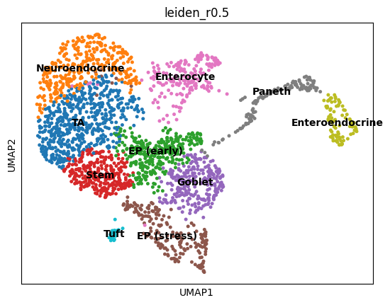

```python
# plot umap with leiden algorithm (resolution = 0.5)
sc.pl.umap(data, color = ['leiden_r0.5'], legend_loc = 'on data')
```

#### **PAGA (Leiden Algorithm, resolution = 0.5)**

Construct the PAGA for the UMAP embedding with the Leiden clustering algorithm at resolution = 0.5.

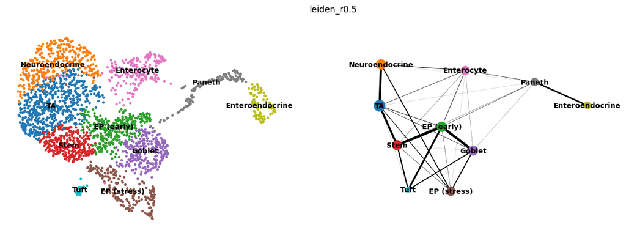

```python
# construct and plot paga with leiden algorithm (resolution = 0.5)
sc.tl.paga(data, groups = 'leiden_r0.5')
sc.pl.paga_compare(data, basis = 'umap')
```

## **References**

- Adam L. Haber. (n.d.). A single-cell survey of the small intestinal epithelium | Nature. https://www.nature.com/articles/nature24489
- Blondel, V. D., Guillaume, J.-L., Lambiotte, R., & Lefebvre, E. (2008). Fast unfolding of communities in large networks. Journal of Statistical Mechanics: Theory and Experiment, 2008(10), P10008. https://doi.org/10.1088/1742-5468/2008/10/P10008
- Lambiotte, R., Delvenne, J.-C., & Barahona, M. (2014). Laplacian Dynamics and Multiscale Modular Structure in Networks. IEEE Transactions on Network Science and Engineering, 1(2), 76–90. https://doi.org/10.1109/TNSE.2015.2391998
- Slovin, S., Carissimo, A., Panariello, F., Grimaldi, A., Bouché, V., Gambardella, G., & Cacchiarelli, D. (2021). Single-Cell RNA Sequencing Analysis: A Step-by-Step Overview. Methods in Molecular Biology (Clifton, N.J.), 2284, 343–365. https://doi.org/10.1007/978-1-0716-1307-8_19
- Traag, V. A., Waltman, L., & van Eck, N. J. (2019). From Louvain to Leiden: Guaranteeing well-connected communities. Scientific Reports, 9(1), Article 1. https://doi.org/10.1038/s41598-019-41695-z
- Wolf, F. A., Hamey, F. K., Plass, M., Solana, J., Dahlin, J. S., Göttgens, B., Rajewsky, N., Simon, L., & Theis, F. J. (2019). PAGA: Graph abstraction reconciles clustering with trajectory inference through a topology preserving map of single cells. Genome Biology, 20(1), 59. https://doi.org/10.1186/s13059-019-1663-x